# Chapter 4 - Dimension Reduction

# Principal Component Analysis

Principal Component Analysis (PCA) is a method used to reduce the number of dimensions in a matrix, this relies on SVD.

The "Principle Components" are the new columns (dimensions) after rotating our data.

## Reducing to $k$ dimensions

When we perform SVD and rotate our data inline with dimensions which maximised the variations in our data, we get our columns of $U$ ordered by how much variance of the original data they explain. The scale of this is given by the elements in $S$.

The "principle components" are the new dimensions/features after rotating our data. The rotated dataset in the direction of principal components is given by $US$.

Our goal is to reduce the dimensions of our dataset. We only want the $k$ most important dimensions and can discard the rest.

Because our data is ordered by importance (the variance in each dimension), we keep only the first $k$ columns of $U$ and first $k$ rows and columns of $S$.

**This new matrix $X' = U'S'$ is the reduced dimension data set that we can now use in our machine learning models**

[figure not shown]

The decomposition and subsequent removal of less important principle components can be considered equivalent to our function:

$$f(X) \rightarrow X'$$

To transform our data back to the original dimensions we multiply:

$U'S'$ by $V^T$'. Where $V^T$' is the first $k$ rows of $V^T$.

$$ X'' = U'S' V^{T}{'} $$

[figure not shown]

This is equivalent to the function $g(X')$ discussed in the previous section.

$$g(X') \rightarrow X''$$

The difference between $X''$ and $X$ gives us the *quality of the dimension reduction process*.

Each principal component will **explain some amount of the variance of the original data**. The first component will explain the largest amount, then decreasing from there.

If we take $k = p$ (new columns = old columns), the components of our decomposition will (in theory) explain all the variance of the original data.

When we take $k~<~p$ then the explained variance of our new reduced data will be **less** than that of the full decomposition.

**By removing principle components, we remove some explained variance. However, by removing the components in order of least to most important we can still explain much of the variance.**

We will use a ratio of how much variance is explained by our new data when compared to using all principle components.

## Implementing PCA

Thankfully, we **do not** need to directly implement this matrix decomposition ourselves. As with many machine learning topics, there is class within `sklearn` that performs the necessary steps to decompose our data and remove the specified number of components.

To perform PCA our data needs to be properly scaled, which `sklearn` handles itself.

The most important hyperparameter for using PCA is the **value of $k$, how many components we want.**

As with all hyperparameters in `sklearn` you can optimise a model with hyperparameter tuning.

Instead of using the notation of $k$, `sklearn` has the parameter `n_components` which describes the same thing; how many components we want our final data to have.

## Data Example

We are going to use a new data set called `high_dimension`. This was a data set created to practice classification problems with.

```python
from sklearn.decomposition import PCA
import numpy as np
import matplotlib.pyplot as plt
%matplotlib inline
```

```python
high_dim = np.loadtxt("../../data/high_dimensions.csv", delimiter=",")
```

The final column of our data set is the target column `y`.

We will be using data throughout this course that has been stored with features `X` and targets `y` in the same file. Given `n` columns we will take the `n`th column as `y` and the `n` to `n-1` columns as `X`. We will then reduce the dimensionality of `X` and explore any relationships with `y`.

```python
high_dim.shape
```

```
(1000, 101)
```

```python
# Splitting the data set
X = high_dim[:,0:-1]
y = high_dim[:,-1]
unique_y, y_counts = np.unique(y, return_counts=True)

print("X shape:", X.shape)
print("y shape:", y.shape)
print("Unique values of y: ", unique_y)
print("Counts of y: ", y_counts)
```

```
X shape: (1000, 100)
y shape: (1000,)
Unique values of y:  [0. 1.]
Counts of y:  [400 600]
```

The target values in `y` are $0$ and $1$, with counts of $400$ and $600$ respectively.

We now have a data set `X` of 1000 rows and 100 features.

- $n = 1000$
- $p = 100$

This is clearly too many for us to plot or analyse one by one. We are going to reduce the number of dimensions to $k=5$.

```python
k = 5

# Create PCA object
pca = PCA(n_components=k, random_state=123)

# Fit the PCA object to the data (performs SVD and reduce dimensions)
pca.fit(X);
```

```python
# Transform the data into reduced dimensions (Remove components)
X_reduced = pca.transform(X)

X_reduced.shape
```

```
(1000, 5)
```

Our new data `X_reduced` has $n$ rows and $k$ dimensions.

From the `pca` object we can get characteristic properties of the components.

Firstly we get the principle components found themselves, given by `pca.components_`, these are vectors in our original feature space. The vectors represent a direction of maximum variance. While interesting, they aren't hugely useful to us right now.

Each of our 5 components will contain 100 values. Each value in the component corresponds to the projection of the original feature column to the new principal component.

```python
# Shape of resulting matrix
pca.components_.shape
```

```
(5, 100)
```

```python
# Shape of single component
pca.components_[0].shape
```

```
(100,)
```

```python
# The first component of the PCA in the original data space
pca.components_[0]
```

```
array([ 9.83252678e-03,  4.76472434e-03, -3.16905555e-03, -7.14122334e-03,
       -5.79596103e-02,  1.42736855e-03, -1.76116886e-02,  5.27744866e-03,
       -8.32168383e-04, -1.12726592e-02, -1.43198549e-02, -5.74253256e-03,
        6.75152856e-03,  2.49022611e-02, -4.90376194e-03, -2.47862708e-02,
       -1.97612304e-02, -2.45953118e-02, -6.98866851e-03,  1.96230471e-02,
        5.61537858e-03,  8.89482161e-03,  1.40062144e-02, -4.15317096e-03,
       -3.84319966e-04, -3.64363821e-03, -1.79229420e-02, -1.22176406e-01,
        8.11039677e-03, -1.42068077e-03, -1.84895828e-02,  3.24083475e-02,
       -5.35944179e-02, -3.21312456e-03, -4.04992988e-03, -1.40910190e-02,
        6.18834527e-03, -1.78383675e-03, -6.92179109e-03, -3.34858592e-03,
       -8.54438609e-03, -4.13364951e-03,  5.43110723e-03,  1.07621707e-03,
        2.97853282e-03,  1.95612726e-02,  5.16437271e-03,  3.84753003e-03,
       -1.94893205e-02, -3.15639144e-03,  1.63061572e-02,  5.97384345e-03,
       -9.20746181e-02, -5.80697561e-01,  1.33261906e-02,  4.68595588e-03,
       -4.72105838e-01, -1.06158026e-03, -1.13012712e-02, -7.59243393e-03,
        3.65532296e-01,  1.25635430e-02, -2.99190447e-03, -2.65202481e-03,
       -1.18532025e-02,  1.83804815e-02,  3.21361587e-03, -8.45085574e-03,
        2.01024008e-02, -4.66931082e-03,  1.06255172e-02, -2.02288080e-02,
       -2.93707145e-04, -6.06288670e-03,  1.33761904e-02,  1.25343245e-01,
        9.98573614e-03, -2.08467847e-03, -1.89043464e-03,  1.22939824e-02,
       -9.54787225e-02, -7.06389230e-03, -4.89799637e-01,  1.38916966e-02,
        3.64044926e-04,  1.51160562e-02, -5.46704242e-03, -5.44902169e-03,
        8.04758911e-03,  5.59785147e-03,  1.80996122e-02, -4.36491669e-03,
        1.94050524e-02, -1.03448657e-04, -1.48657901e-02,  1.42286887e-02,
        5.26796589e-03,  8.82533943e-03, -1.39178672e-02,  3.86624374e-04])
```

Next we have the explained variance of each component, given by `pca.explained_variance_`.

```python
pca.explained_variance_
```

```
array([8.22194887, 7.11047283, 5.57611784, 4.63638452, 4.12950926])
```

We can see here that the first component explains more variance than the second and so on.

However, it is more useful for us to look at the **explained variance ratio** of each component.

This will help us judge how useful each component is at explaining the variance of the data.

```python
evr = pca.explained_variance_ratio_

# Produce a percentage
evr_pct = evr*100

print("The explained variance of the first component is: {} %".format(evr_pct[0].round(2)))
print("The explained variance of the second component is: {} %".format(evr_pct[1].round(2)))
print("The total explained variance of all {} components are: {} %".format(k, evr_pct.sum().round(2)))
```

```
The explained variance of the first component is: 6.32 %
The explained variance of the second component is: 5.47 %
The total explained variance of all 5 components are: 22.82 %
```

We can see here that our first component explains some amount of the variance, and all of the $k=5$ components explain the more of the variance, but information about the original data is clearly lost!

**Exercise 1:**

Perform PCA again on $X$, this time with $n\_components=10$, what is the difference in **total** explained variance between using five and ten components? Which number of components might we prefer to use?

```python
# Write your code here
```

# Effects of Dimension Reduction on Models

We are now able to perform PCA on our data set to make new data using principle components. We will now explore what *impact* this has in a supervised machine learning context.

### Visualising data

We are first going to look at the new data in two dimensions. Using our target attribute, we can visualise how our classification model might learn relationships in the new data. Visualising all the data at once is *something we would not be able to do* with our original data.

It's important to note that we have not used `y` yet to train anything, the visualisation shows the *natural spread of the classes using only* `X`.

```python
k = 2

# Create the new PCA object with k=2
pca = PCA(n_components=k)

# Transform the data into two dimensions
X_pca = pca.fit_transform(X)

print("Total variance ratio explained by {} components: {}%".format(k, (pca.explained_variance_ratio_.sum()*100).round(3)))
```

```
Total variance ratio explained by 2 components: 11.791%
```

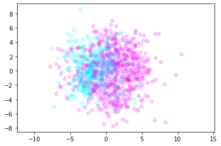

```python
first_dimension = X_pca[:,0]
second_dimension = X_pca[:,1]

# Plotting data in new dimensions
# Adding the colour as the class labels lets us see
# how the components correspond to target class values
plt.scatter(x=first_dimension, y=second_dimension, c=y, alpha=0.2, cmap="cool")
plt.axis("equal");
```

We can see that based on the target classes the two dimension projection of our data could help predict values as there seems to be some separation occuring.

### Comparing Performance in Prediction

We are going to use a simple, untuned Logistic Regression model to compare how well our reduced dimension data performs compared to the original set.

This is done using the F1 score as our metric with training and test splits.

First the data needs to be centred for fair comparison as PCA does this for us.

```python
from sklearn.linear_model import LogisticRegression
from sklearn.model_selection import train_test_split
from sklearn.metrics import f1_score

# Find the mean of each column used for centring
column_means = np.mean(X, axis=0)

# Center the data
# This helps the PCA perform better
X_centred = X - column_means

# Split the data
X_train, X_test, y_train, y_test = train_test_split(X_centred,
                                                    y,
                                                    test_size=0.33,
                                                    random_state=42)
```

```python
# Train the model
original_model = LogisticRegression().fit(X_train, y_train)

# Generate predictions
y_pred = original_model.predict(X_test)

# Measure performance
original_score = f1_score(y_test, y_pred)

print("Original data score:", original_score)
```

```
Original data score: 0.7931034482758621
```

Let us make a function that does the PCA, model training and prediction steps for us given the input data and number of desired dimensions.

```python
def PCA_train_predict_score(X, y, k, random_state=42):
    """
    Function to perform PCA, generate Logistic Regression model
    evaluating performance of given k components.

    Parameters
    ----------
    X : np.array (n,p)
        Feature data
    y : np.array (n,)
        Target data
    k : int
        Number of components for PCA to return
    random_state : int
        Random seed for train_test_split

    Returns
    -------
    score : float
        f1_score result of model trained.
    """
    # Split the data
    X_train, X_test, y_train, y_test = train_test_split(X,
                                                        y,
                                                        test_size=0.33,
                                                        random_state=random_state)
    # Fit the PCA model on the training data
    pca = PCA(n_components=k).fit(X_train)

    # Apply our learned PCA transformation from the test data on the
    # training and test sets.
    # This puts the test data into the same component factor space as
    # the trained data
    X_train = pca.transform(X_train)
    X_test = pca.transform(X_test)

    # Train the model
    model = LogisticRegression().fit(X_train, y_train)

    # Generate predictions and score the predictions
    # Using f1 score described in Chapter 3
    y_pred = model.predict(X_test)
    score = f1_score(y_test, y_pred)

    return score
```

Reminder - the `f1` score is calculated to measure the performance of prediction using:

$$ F1 = 2 \cdot \frac{precision \cdot recall}{precision + recall} $$

or

$$ F1 = \frac{TP}{TP + \frac{1}{2} (FP + FN)} $$

```python
# The maximum number of components is given by the original feature number
k_max = X.shape[1]

# Create a list of k_values
k_values = list(range(1, k_max + 1))

# Generate F1 scores for each k value of PCA
f1_scores = [PCA_train_predict_score(X, y, k) for k in k_values]
```

[output not shown]

[output cut: 145 more lines]

[output not shown]

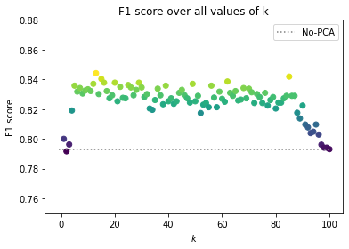

```python
# Plot and compare the resulting performance of different values of k
plt.title("F1 score over all values of k")
plt.xlabel("$k$")
plt.ylabel("F1 score")
plt.ylim(0.75, 0.88)

plt.hlines(y=original_score, xmin=-1, xmax=k_max, label="No-PCA", colors="grey", linestyles="dotted")

plt.scatter(x=k_values, y=f1_scores, c=f1_scores)

plt.legend();
```

We can see from the above data, that choosing to reduce our dimensionality can *improve* our model's predictive performance in some cases. This is because it can remove unimportant information in the original data set: statistical noise.

There are three trends here to note:

- Starting from $k = 1$ the `f1` performance **increases** with increasing $k$. Adding more significant dimensions gives our model more information to train on, producing a better score.
- There is a peak somewhere between $k=5 - 20$. Above this amount our performance gradually declines. This is because our model is overfit to the training data. It is creating principle components using noise not real trends - this propogates through to the model to reduce performance.
- At a higher number of $k$ adding more components **decreases** the model's performance more significantly, as we tend towards $k \rightarrow 100$ the performance of our model gets closer to the value of the model trained without PCA.

From this we can see that selecting the right value of $k$ can **significantly** (~5%) improve our model's predictive performance.

To best determine an optimal value of $k$ we could perform a cross validation for a range of values of $k$. We could then compare the performance of the training and test `f1` scores. We could then choose the value of $k$ with the best test `f1` scores. With the best $k$ value found we would then continue our modelling process.

The method shown in the figure above is a more simplistic version of the cross validation approach. The cross validation approach will provide a more statistically robust result. Instead of using `train_test_split` you could instead use `sklearn.model_selection.cross_validate` or related methods.

Side note: the "true" number of components used to create this data set was $k=10$.

**Exercise 2:**

What value of $k$ has the highest associated F1 score? What does that tell you about our data?

**HINT** Look up the numpy function $np.argmax()$

```python
# Write your code here
```

### Comparing Training Time

As the size of our data gets large, the time taken to train a model increases drastically. One consideration for how many dimensions of data to choose is how long will it take to train our model. We often have trade-offs between accuracy, time and memory contraints in computing.

We are going to modify our `PCA_train_predict_score()` function to measure how long it takes to train a model in addition to the F1 score. We can then compare each model. In this example we are going to just look at how long the model training takes, not how long the whole processing takes.

*We are using a relatively small data set, so the scale of times may be small*

```python
import time

def PCA_train_predict_score_time(X, y, k, random_state=42):
    """
    Function to perform PCA and generate model to check model performance
    and training time of given k components.

    Parameters
    ----------
    X : np.array (n,p)
        Feature data
    y : np.array (n,)
        Target data
    k : int
        Number of components
    random_state : int
        Random seed for train_test_split

    Returns
    -------
    score : float
        f1_score result of model trained.
    training_time : float
        The time taken to train the model
    """
    # Split the data
    X_train, X_test, y_train, y_test = train_test_split(X,
                                                        y,
                                                        test_size=0.33,
                                                        random_state=random_state)
    # Fit the PCA to the training data
    pca = PCA(n_components=k).fit(X_train)

    # Our test data needs to be PCA'd on the original PCA model fit
    X_train = pca.transform(X_train)
    X_test = pca.transform(X_test)

    # Create the model object
    estimator = LogisticRegression()

    # Get the time at the start and end of the model training
    start_time = time.time()
    model = estimator.fit(X_train, y_train)
    finish_time = time.time()

    # Generate predictions and score
    y_pred = model.predict(X_test)
    score = f1_score(y_test, y_pred)

    # Calculate total training time
    training_time = finish_time - start_time

    return score, training_time
```

Generate the time and performance data for each value of $k$ we are interested in.

```python
# The maximum number of components is given by the original feature number
k_max = X.shape[1]

# Create a list of k_values
k_values = list(range(1, k_max + 1))

# Generate F1 scores and model training time for each k value of PCA
f1_scores_times = [PCA_train_predict_score_time(X, y, k) for k in k_values]

# Separate the list of tuples into two lists
f1_scores, times = zip(*f1_scores_times)
```

[output not shown]

[output cut: 145 more lines]

[output not shown]

Getting our non-PCA performance to compare with:

```python
# Split the data
X_train, X_test, y_train, y_test = train_test_split(X_centred,
                                                    y,
                                                    test_size=0.33,
                                                    random_state=42)

# Create the model object
original_estimator = LogisticRegression()

# Get the time at the start and end of the model training
start_time = time.time()
original_model = original_estimator.fit(X_train, y_train)
finish_time = time.time()

# Generate predictions and evalute the performance
y_pred = original_model.predict(X_test)
original_score = f1_score(y_test, y_pred)

# Calculate the time taken to train
original_time = finish_time - start_time
```

Plotting results of the measurements of time taken to train shows that the fewer dimensions used to train the data the faster the model trains.

However, we can see that the *fastest* models to train are **not** the *best performing* models.

There is a trade-off between number of dimensions reduced to, the speed of training and the model's final performance.

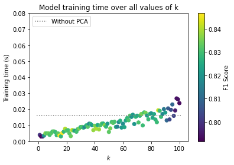

```python
plt.scatter(k_values, times, c=f1_scores)
cbar = plt.colorbar()
cbar.set_label("F1 Score")
plt.title("Model training time over all values of k")
plt.xlabel("$k$")
plt.ylabel("Training time (s)")
plt.ylim(0, 0.08)
plt.hlines(y=original_time, xmin=-1, xmax=101, label="Without PCA", colors="grey", linestyles="dotted")
plt.legend(loc="upper left");
```

We can see that the lowest $k$ have the fastest speed, but low performance. Higher $k$ improve the model performance and are faster than the original model, however increasing $k$ too much decreases performance and speed.

**Exercise 3:**

Using $X$ fit a PCA model with $k = 50$. Plot the cumulative sum of variance explained ratio of each component.

**HINT:** use the numpy $np.cumsum()$ function

```python
# Write your code here
```

# PCA Variants

### Kernal PCA

The PCA method discussed so far creates a set of dimensions that are orthogonal to each other (at right angles). This is a good assumption for some data; however this linear model will not capture important aspects of all data.

The relationships between some features may not be linear, by using Kernel PCA we can capture this non-linear behaviour.

One common example of non-linear data properties that linear PCA cannot adequately express is circularly separated data.

An example of this is given below.

```python
# Load in our concentric circle data
circle_data = np.loadtxt("../../data/circles.csv", delimiter=",")
```

```python
# Split X and Y data
X_circles, y_circles = circle_data[:,0:-1], circle_data[:,-1]
```

In this data set we have three columns, the first two are the continuous data features. The third is a binary target attribute.

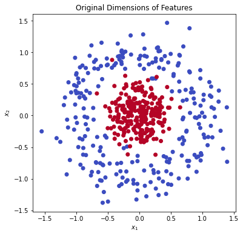

```python
plt.figure(figsize=(6, 6))
plt.title("Original Dimensions of Features")
plt.xlabel("$x_1$")
plt.ylabel("$x_2$")
plt.axis("equal")
plt.scatter(x=X_circles[:,0], y=X_circles[:,1], c=y_circles, cmap="coolwarm");
```

**Exercise 4:**

Using $X\_circles$ perform *linear* PCA with $k = 2$. Plot the resulting new dimensions of data. Calculate the **total** explained variance ratio of the model and discuss why it may be difficult for a linear machine learning model to learn the pattern of this data.

```python
# Write your code here
```

Using Kernel PCA we can use the non-linear structure of the data to find the best components.

We have multiple options for the choice of kernel that is most appropriate, these include:

- "linear" - fits a linear kernel
- "poly" - fits a polynomial (function of order > 1) function
- "rbf" - fits a radial basis function kernel
- and more!

For more information on kernels and how `sklearn` defines them check [here](https://scikit-learn.org/stable/modules/metrics.html#metrics).

Our data is in concentric circles, so we are going to choose the **radial basis function** as it can represent circles.

The parameter `gamma` is the kernel coefficient, which determines the strength of the kernel function's effect.

```python
from sklearn.decomposition import KernelPCA

kpca = KernelPCA(n_components=2, kernel="rbf", gamma=2)

X_kpca = kpca.fit_transform(X_circles)
```

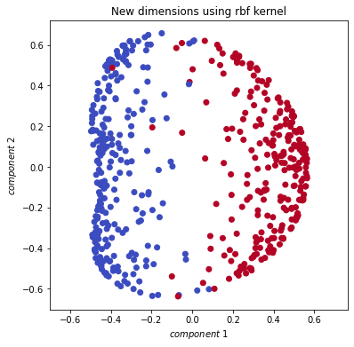

```python
plt.figure(figsize=(6, 6))
plt.title("New dimensions using rbf kernel")
plt.xlabel("$component~1$")
plt.ylabel("$component~2$")
plt.axis("equal")
plt.scatter(x=X_kpca[:,0], y=X_kpca[:,1], c=y_circles, cmap="coolwarm");
```

This makes the difference between the two concentric circles in the original data clearer in the new dimensions, they are better separated.

Our machine learning model would find it easier to learn the difference between the classes in this case rather than when the data was in circles.

A really simple model, such as defining the predicted class purely based on the value of `component 1` would perform very well!

**Exercise 5:**

Perform Kernel PCA on the $X\_circles$ data set using the "rbf" kernel and $k = 2$.

Use values of $gamma=1$ and $gamma=7$. What effect does this have?

Plot the results of each value.

```python
# Write your code here
```

### Incremental PCA

PCA is a very powerful tool in reducing the size of our data. However, traditional methods for calculating the SVD of a data set require all the data to be held within the computer memory at once.

This can be impractical for data sets which are larger than our computer memory.

In this case we can use Incremental PCA, which partially fits the PCA over batches of data samples. This means we are only fitting to the amount of data in one single batch of data at any one time, reducing the size of memory needed.

The `sklearn` implementation of this method by default sets the `batch_size= 5 * n_features`.

This method will produce different, but similar principle components to linear PCA.

*This example uses data that would fit in the computer memory as a toy example.*

**Exercise 6:**

Using $ipca\_20$ fit the data to $X$. Compare the total variance explained ratio of $ipca$ with the original PCA method using $k=20$.

```python
from sklearn.decomposition import IncrementalPCA

ipca_20 = IncrementalPCA(n_components=20)

# Write your code here
```

# Factor Analysis

PCA and it's variants are one subset of dimension reduction for analysis methods.

When performing dimension reduction techniques we map our data from it's original space to a new space that represents combinations of features. These combinations of features have meaning as latent variables. We have different approaches to the mapping / combining of features. By choosing different methods we can interpret our data in different ways.

Another approach, which is similar to PCA, but with key difference is Factor Analysis. Instead of principal components as our resulting space to analse we instead have factors.

The classical PCA we looked at first has the following characteristics:

- Data is continuous
- Components are orthogonal / not correlated

Approaches in Factor Analyis allow us to use different data types other than continuous variables, and let us analyse latent variables in different ways.

Our features are a combination of weighted factors. We can specify how many factors we want to find in our data

Consider a data set $X$ with $p$ features/variables $X_1, X_2, ..., X_p$.

After performing Factor Analysis we find $m$ factors, where $m < p$ (remember we are trying to reduce our dimensions!) $F_1, F_2, ..., F_m$.

Each feature $X_i$ is: $$X_i = a_{i1}F_1 + a_{i2}F_2 + ... +a_{im}F_m + e_i $$

Where $a_i$'s are the factor score - explaining how important each factor is in explaining the feature. The value $e_i$ is the error that cannot be explained by a factor.

Some factors will explain some features well, and have high factor scores. Some will have low factor scores, meaning the factor does not explain the feature well. The goal of factor analysis is to separate out features such that combinations of features are explained by separate factors.

Factor Analysis can be performed in a similar way to PCA using `sklearn.decomposition.FactorAnalysis`. This method of factor analysis uses maximum likelihood estimate to build the factors - and as such its performance can be evaluated using a log-likelihood.

```python
from sklearn.decomposition import FactorAnalysis

high_dim = np.loadtxt("../../data/high_dimensions.csv", delimiter=",")

X, y = high_dim[:,0:-1], high_dim[:,-1]

# Create 10 factors to analyse
fa = FactorAnalysis(n_components=10).fit(X)

factors = fa.transform(X)

# look at first factor
factors[:,0]
```

[output not shown]

[output cut: 195 more lines]

[output not shown]

```python
fa.score(X)
```

```
-147.45983508288884
```

## Further Factor Analysis

The above basic method of Factor Analysis can be very powerful. It is often better to use factor analysis for exploratory data analysis. Factor Analysis assumes that the noise in each feature is gaussian, but not the same distribution for each feature.

The `sklearn` implimentation above is used on continuous data. However, we will often instead want to work with categorical data instead (ordinal or nominal). There are other methods of FA that can be used in different data type situations.

These are beyond the scope of this course, but added for reference.

- Using a contingency table (cross-tab or pivot): Correspondence Analysis (CA)
- More than 2 features that are all categorical: Multiple Correspondence Analysis (MCA)
- Groups of Categorical *or* numerical features, not both: Multiple Factor Analysis (MFA)
- Both categorical and numerical features: Factor Analysis of Mixed Data (FAMD)

In Python, these methods can be used in a similar syntax to `sklearn` using the `prince` packages. For more information on the `prince` package, available on `pip` see [the prince documentation on GitHub](https://github.com/MaxHalford/prince)

# Dimension Reduction for Visualisation

PCA is a common and powerful method for dimension reduction, however, there are limitations associated with it.

We have seen that reducing the data leads to potential model performance increases, as well and increases in training speed. We can also use dimension reduction as a method for **visualising high dimension data**.

Data with large numbers of dimensions (columns) is hard to comprehend, we cannot *see* the data all at once. The natural structure between features will escape us visually if our data has more than three dimensions.

By reducing the number of dimensions in our data set we can see some of the relationships between each sample.

We can achieve this with PCA, but we will look at another method for doing so. Each method has benefits and challenges associated.

## t-SNE

One other method to reduce the data dimensionality for visualisation is t-distributed Stochastic Neighbour Embedding (t-SNE).

Let's break down the terms in that name:

- Stochastic - this method uses random processes
- Neighbour - the method uses the affinity between data near each sample
- Embedding - the method creates new vector spaces
- t-distributed - the method creates joint probabilities of the original dimension affinities

In short; the t-SNE method works out the local structures in the data by mapping similar data near each other in the new dimension space. The new dimension space typically has two dimensions.

This method uses a *Nearest-Neighbour* search, in a similar way to the KNN algorithm, it is therefore important that we scale the data to be within the same range before we pass it to the t-SNE dimension reducer.

(In our case $X$ is already adequately scaled)

**Warning: t-SNE can be very slow**

Below we are reducing the high dimension data set $X$ used for linear-PCA.

```python
from sklearn.manifold import TSNE

# The random state initialization can significantly impact our output
tnse = TSNE(n_components=2, random_state=123)

# Fit transform the data into the t-SNE embedding dimensions
X_tsne = tnse.fit_transform(X)
```

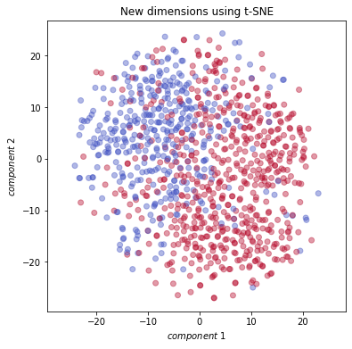

```python
plt.figure(figsize=(6, 6))
plt.title("New dimensions using t-SNE")
plt.xlabel("$component~1$")
plt.ylabel("$component~2$")
plt.axis("equal")
plt.scatter(x=X_tsne[:,0], y=X_tsne[:,1], c=y, alpha=0.4, cmap="coolwarm");
```

We can now look at our data which was 100 dimensions and understand *something* about it's structure.

**Exercise 7:**

Using "../../data/bikes.csv", keep in only the boolean and numeric data, clean the data, visualise the data in 2D using t-SNE and the target "count" attribute.

Compare t-SNE and PCA in 2D for this data.

What value of $k$ is needed have the total explained variance ratio $> 0.8$ for linear PCA?

```python
# Write your code here
```

# Summary

This chapter has been an introduction into dimension reduction techniques. There are many decisions to make regarding how/whether you reduce the dimensionality of your data. These fall under the general categories of *method selection* and *desired dimension number*.

We have covered the theory of lossy compression, this showed how we reduce information using encoding and decoding and the effect this has. We then looked at the linear algebra method of SVD which allowed us to break down our data into informative component matrices. Using this SVD technique we could then analyse the principle components of the data, and subsequently reduce the dimensionality of the data.

We then looked at the effects of reducing our data dimensions, which were changes to model prediction performance and training time.

Next, there was a discussion of some of the issues with PCA, inlcuding it's linear assumptions and memory requirements, which naturally lead to alternative implementations:

- Kernel PCA for non-linear dimension reduction
- Incremental PCA for data sets greater than the memory of our machine

We also looked at and discussed when to use different Factor Analysis methods.

The next section focused on a different method of dimension reduction to achieve useful data visualisation; t-SNE.

Dimension reduction can be used in two ways, to gather greater insights into our data with exploratory data analysis, visualisation and for improving our machine learning model's performance.

**Next Chapter: Clustering**

We have been exploring elements of our training data in this chapter, next we will look into understanding the structure of the data sets in greater depth. We will look at clustering as a way to group our data using a variety of methods that give insight on our data.